# RFM

- الف - پدیده چه الزامات و شرایطی را دارد، بسته به نوع موضوع باید تشریح شود که چه هدفی از مدلسازی دنبال میشود.
- ب - فرضیات حاکم بر پدیده چیست؟ متغیرها و پارامترهای مختلف چه تاثیری بر تابع هدف دارند؟
- ج - مدل با چه ابزاری در ریاضیات قابل تحلیل و بررسی است؟ ممکن است شما به آن ابزار تسلط نداشته باشید، لازم است کمی راجع به آن توضیح دهید.
- د - نتیجه گیری، یعنی مدل نوشته شده چه نتایجی را در اختیار ما میگذارد و ارزش توجه به آنرا بیان کنید. به بیان دیگر مزیتهای مدل چیست.

# مدلسازی پروازهای عبوری از فضای ایران

[figure not shown]

|  | نیازمندی ها |
| --- | --- |
| ✈️ **داده های پروازی** | رکورد پروازهای عبوری |
| 💲 **اطلاعات صورتحساب** | نرخ پروازهای عبوری بر حسب مسیر |
| 🗓 **تاریخ پروازها** | برچسب زمان ورود |
| 🛂 **شناسه شرکت های هواپیمایی** | کد یکتا ایکائو |
| 📈 **تاریخچه داده ها** | بازه زمانی کافی برای محاسبه الگو |

|  | شرایط و ملاحظات |
| --- | --- |
| ✈️ **الگوی پروازی** | فصلی، چارتری، برنامه، غیر برنامه ای |
| 🔄 **تغییرات مسیرهای هوایی** | بسته بودن مسیر، تداخل مسیرها یا راه های هوایی جدید |
| 🌍 **مخاطرات تأثیرات جغرافیایی** | تحریم،مناطق جنگی یا روابط دیپلماتیک |
| 📉 **حساسیت نرخ** | ارزیابی کشش → دوری ایرلاین ها از فضای هوایی گران |
| 💾 **کیفیت اطلاعات** | برچسب های زمانی نادقیق یا اطلاعات مالی اشتباه |

| هدف | مزیت |
| --- | --- |
| دسته بندی شرکت های هواپیمایی | تمرکز بر مشتری های بالقوه |
| پیش بینی درآمدهای عبوری | برنامه ریزی بودجه و زیرساخت |
| تحلیل تاثیرات سیاست گذاری | تنظیم نرخ بر اساس رفتار |
| بهینه سازی نرخ هوایی | ایجاد تعادل بین درآمد و ترافیک |

### 🛍️ Up-Selling, Cross-Selling, and Repeat Purchases

A reduction in customer churn directly uplifts the revenue. With customer behavior modeling, businesses can easily look at customer segments that are ripe for up-selling, cross-selling, and repeat purchases. These three sales maximizing tactics will maximize CLTV and also bring in more dollars to the business coffers.

| **Concept** | **Definition** | **Example** | **Goal** |
| --- | --- | --- | --- |
| **Up-Selling** | Selling a **more expensive or upgraded** version of the product the customer is considering. | Customer wants a basic phone → you suggest a premium model with better features. | Increase the **order value**. |
| **Cross-Selling** | Selling **related or complementary** products to what the customer is buying. | Customer buys a laptop → you suggest a laptop bag or mouse. | Increase the **basket size**. |
| **Repeat Purchase** | Customer **returns to buy again** after a previous purchase. | Customer buys shoes → comes back next month to buy another pair. | Build **loyalty** and **lifetime value**. |

### 📈 Concept Relationships

$$ \text{Up-Selling:} \quad \text{Encourage buying a higher-tier product (} P^+ \text{)} $$

$$ \text{Cross-Selling:} \quad \text{Encourage buying complementary products (} P + Q \text{)} $$

$$ \text{Repeat Purchase:} \quad \text{Customer returns for } P \text{ after time } t $$

### 🧠 Quick Mnemonics

- Up-Sell ↔ Upgrade the product
- Cross-Sell ↔ Add related products
- Repeat Purchase ↔ Retain and resell over time

# 📋 Agenda

## CLV

### تخمین سود آتی به ازای هر مشتری با استفاده از نرخ حفظ مشتری و نرخ تنزیل

## FBR

### تمرکز بر بهینه سازی درآمدهای حوزه هوانوردی

## RFM

### بخش بندی مشتریان بر اساس الگو های رفتاری گذشته

| **Model** | **Variable / Parameter** | **Symbol** | **Description** |
| --- | --- | --- | --- |
| **CLV** *(Customer Lifetime Value)* | Margin per period | $m$ | سود کسب شده به ازای هر مشتری در واحد زمان |
|  | Retention rate | $r$ | احتمال ادامه رابطه مشتری در دوره بعدی |
|  | Discount rate | $d$ | ارزش فعلی جریان‌های نقدی در هر دوره |
|  | CLV formula | $CLV$ | $CLV = \frac{m \cdot r}{1 -r + d }$ |
|  | Lifetime revenue projection | – | پیش‌بینی سود کل از یک مشتری |
| **FBR** *(Flight-Based Revenue)* | Number of overflights | $N$ | تعداد کل پروازهای عبوری از حریم هوایی |
|  | Distance per flight | $D$ | میانگین مسافت طی شده در حریم هوایی |
|  | Overflight fee rate | $R$ | هزینه به ازای هر ناتیکال مایل |
|  | Elasticity of demand | $E_d$ | (کشش) $R$ حساسیت پروازها به تغییرات |
|  | Scenario adjustment factors | – | برای مدل‌سازی تغییرات جغرافیایی، فصلی یا رقابتی استفاده می‌شود |
|  | Total revenue | $TR$ | $TR = N \times D \times R$ |
| **RFM** *(Recency–Frequency–Monetary)* | Recency | $R$ | زمان سپری شده از آخرین فعالیت مشتری (smaller = more recent) |
|  | Frequency | $F$ | تعداد فعالیت مشتری (e.g., purchases, flights) |
|  | Monetary | $M$ | کل مبلغی که مشتری پرداخت کرده است |
|  | RFM score | – | R، F، M رتبه‌بندی ترکیبی یا چندک |
|  | Segmentation | – | گروه‌بندی مشتریان (e.g., champions, at risk, lost) |
|  | Combined into a single number | – | $\text{RFM}_{i} = 100 \cdot R_{i}^* + 10 \cdot F_{i}^* + M_{i}^*$ |

## Customer Lifetime Value (CLV) — Mathematical Definitions

The Customer Lifetime Value (CLV) formula calculates the total revenue a business can expect from a single customer over the entire duration of their relationship. It helps businesses make data-driven decisions about marketing, sales, and customer retention strategies.

### 🧮 1. Simple CLV Formula

- 🎲 Their chance of staying (retention),
- 💰 The value they bring (margin),
- ⌛ The decreasing value of future money (discounting).

Assuming constant margin ( m ), retention rate ( r ), and discount rate ( d ):

$$ \text{CLV} = \frac{m \cdot r}{1 + d - r } $$

#### 📚 CLV Parameters Table

| **Symbol** | **Name** | **Description** |
| --- | --- | --- |
| $m$ | Margin per period | **Profit** earned **per customer per period**, assumed **constant** over time. |
| $r$ | Retention rate | **Probability** that a customer **remains active** in the next period (value between 0 and 1). |
| $d$ | Discount rate | Reflects how much **time value of money** — future profits are discounted; higher ( d ) means future money is worth less. |

If:

- $𝑟$ is high (close to 1) → Customers stay longer → Higher CLV.
- $𝑚$ is high → More profit per period → Higher CLV.
- $𝑑$ is low → Future money is almost as good as today → Higher CLV.

### 📐 Logic Behind the CLV Formula

It is based on geometric series logic. Assume:

- Time is divided into discrete periods (e.g., months, years).
- In each period:
  - The customer stays with probability ( r ).
  - If they stay, they bring margin ( m ).
  - Future profits are discounted at rate ( d ).

So the expected profit stream (CLV) is: $$ \text{CLV} = m \cdot r \cdot \frac{1}{1 + d} + m \cdot r^2 \cdot \frac{1}{(1 + d)^2} + m \cdot r^3 \cdot \frac{1}{(1 + d)^3} + \cdots $$

This is an infinite geometric series of the form:

$$ \text{CLV} = m \cdot \sum_{t=1}^{\infty} \left( \frac{r}{1 + d} \right)^t $$ This is a geometric series of the form:

$$ \sum_{t=1}^{\infty} x^t = \frac{x}{1 - x}, \quad \text{for } |x| < 1 $$

Let:

$$ x = \frac{r}{1 + d} $$

Then:

$$ \sum_{t=1}^{\infty} \left( \frac{r}{1 + d} \right)^t = \frac{\frac{r}{1 + d}}{{1 - \frac{r}{1 + d}}} = \frac{r}{1 + d - r} $$

So this series converges when:

$$ \frac{r}{1 + d} < 1 $$

Substitute back into the original expression:

$$ \text{CLV} = \frac{ m \cdot r}{1 + d - r} $$

### 📦 2. Discounted Revenue CLV

If we track revenue/profit over time:

$$ \text{CLV} = \sum_{t=1}^{T} \frac{r_t \cdot m_t}{(1 + d)^t} $$

### 📦 2. Discounted Revenue CLV

If we track revenue/profit over time:

$$ \text{CLV} = \sum_{t=1}^{T} \frac{r_t \cdot m_t}{(1 + d)^t} $$

- ( $T$ ): customer lifetime (in time periods)
- ( $r_t$ ): retention indicator or probability at time ( t )
- ( $m_t$ ): profit or revenue at time ( t )
- ( $d$ ): discount rate

#### How to Estimate Retention and Discount Rate from Raw Data:

- Method 1: Cohort Retention Group customers by when they first transacted (e.g., month joined).

Track whether they made purchases in each future period.

Calculate: $$ r = \frac{\text{Number of customers who stayed}}{\text{Number of customers at start}} $$

- Method 2: Overall Retention Rate If you only have aggregated customer history:

$$ r = 1 − Churn Rate $$

And churn rate is: $$ Churn Rate = \frac{\text{Number of lost customers}}{\text{Total customers at the start}} $$

✅ Common Approaches

- Use a fixed discount rate (e.g., 10% annual = d = 0.10) — commonly used if no financial modeling is available.
- Use your company’s cost of capital or desired ROI.
- You can also model d based on average risk or inflation in your industry.

Example: If your company expects a 12% return per year, then: $$ d = 0.12 $$

If you are calculating monthly:

$$ d_{\text{monthly}} = \frac{0.12}{12} = 0.01 $$

### 📈 3. Transactional CLV (per customer)

Transactional CLV (Customer Lifetime Value) refers to a modeling approach that calculates CLV based on actual, observed transaction data, such as:

- When each customer made purchases
- How much they spent
- How frequently they bought over time

It focuses on tracking customer behavior over time, instead of assuming average behaviors or relying on simplified formulas.

$$ \text{CLV}_i = \sum_{j=1}^{n_i} \frac{p_{ij}}{(1 + d)^{t_{ij}}} $$

- ( i ): customer index
- ( j ): transaction index
- ( $p_{ij}$ ): profit from transaction ( j ) by customer ( i )
- ( $t_{ij}$ ): time since acquisition or from now
- ( $d$ ): discount rate

[output not shown]

⌚ For C123:

| Customer | Total Transactions | Total Amount | Avg Amount |
| --- | --- | --- | --- |
| C123 | 2 | 80 + 20 = 100 | $50 |
| C456 | 1 | 200 | $200 |

### 💡 4. Predictive CLV (Simplified)

If we estimate future values from behavioral features:

$$ \text{CLV}_i = \text{ExpectedFrequency}_i \times \text{ExpectedValue}_i \times \text{ExpectedLifespan}_i $$

Example: If a customer spends \$50 on average per purchase, makes 3 purchases per year, and remains a customer for 5 years, then the CLV would be: $$ \text{CLV} = \\$50 \cdot 3 \cdot 5 = \\$750 $$ Each component can be predicted via machine learning or statistics.

### 🔮 5. Probabilistic Model (BG/NBD + Gamma-Gamma)

For advanced forecasting, you can use probabilistic models. The most basic formula we use is as follows:

$$ \text{CLTV} = \text{Expected Number of Transaction} \cdot \text{Expected Average Profit} $$

#### BG/NBD (Buy-Till-You-Die)

Estimates future purchases based on:

- Transaction Process (Buy) → Beta Geometric Distribution
- Dropout process (Till You Die) → Negative Binominal Distribution

##### Expected future transactions:

$$ E[X_i(t)] = \text{Estimated using BG/NBD model} $$

#### Gamma-Gamma Model (Expected average transaction value):

Estimates average transaction value assuming:

- Transaction amounts follow a Gamma distribution
- Amounts are independent of frequency

$$ E[M_i] = \text{Estimated using Gamma-Gamma model} $$

#### Full model:

$$ \text{CLV}_i = E[X_i(t)] \cdot E[M_i] $$

### 📋 CLV Model Summary Table

| **Model** | **Formula** | **Use Case** |
| --- | --- | --- |
| **Simple CLV** | $\frac{m \cdot r}{1 + d - r}$ | Subscription, constant margin & churn |
| **Discounted Revenue** | $\sum_{t=1}^{T} \frac{r_t \cdot m_t}{(1 + d)^t}$ | Time-based value with discounting |
| **Transactional CLV** | $\sum_{j=1}^{n_i} \frac{p_{ij}}{(1 + d)^{t_{ij}}}$ | Historical transaction-level data |
| **Predictive CLV** | $\text{Freq}_i \times \text{Value}_i \times \text{Lifespan}_i$ | ML-based estimation |
| **BG/NBD + Gamma-Gamma** | $E[X_i(t)] \cdot E[M_i]$ | Probabilistic, behavioral prediction |

# ✈️ Flight-Based Revenue (FBR) Model

## 📌 What is FBR?

**Flight-Based Revenue (FBR)** is a *quantitative framework* used by countries to estimate and optimize the revenue earned from aircraft that **fly over their airspace** (without landing). It’s especially critical for countries located on major international flight routes — like Iran, Turkey, or Egypt.

## 🎯 Why FBR Matters

Countries charge airlines **overflight fees** based on factors like:

- Distance flown over the country.
- Aircraft weight or category.
- Route type (e.g., commercial, cargo).

These revenues serve as:

- A **major non-oil income source**.
- A **sensitive indicator** to geopolitical and competitive dynamics.

## 🔢 The Core Formula

$$ \text{Total Revenue (TR)} = N \times D \times R $$

Where:

- (N): Number of overflights
- (D): Average distance flown over national airspace
- (R): Overflight fee per nautical mile

## 🧠 Strategic Components

| Component | Description |
| --- | --- |
| Overflight Count ((N)) | Depends on route demand, airline routing, and alternatives |
| Distance ((D)) | Typically fixed, based on geography |
| Fee Rate ((R)) | Decision variable—raising it increases revenue but may reduce demand |
| Total Revenue ((TR)) | Output from model—reflects income from overflight charges |

## 🧮 Optimization Scenario

If raising the fee from \$50 to \$55 causes a **3% drop** in flights, but each remaining flight brings in more:

$$ \text{New Revenue} = 0.97N \cdot D \cdot 55 = 1.067 \cdot (N \cdot D \cdot 50) $$

This results in a **6.7% increase** in revenue — assuming only a small reduction in traffic volume.

## 🧩 Use Cases & Benefits

- 📊 **Revenue Forecasting**
- 🛫 **Route competition analysis** (e.g., avoiding detours through neighbors)
- ⚖️ **Policy decision-making** (e.g., fee adjustments during sanctions or conflict)

## ✅ Conclusion

The **FBR model** is a strategic tool that blends **economics, forecasting, and optimization** to help countries:

- Maximize overflight income
- Compete effectively for international traffic
- Respond intelligently to geopolitical shifts
- Ensure sustainable, data-driven aviation policy

## 📊 RFM Analysis

Let:

- ( $C = \{c_{1}, c_{2}, \ldots, c_n\}$ ): Set of customers
- ( $T$ ): Reference date (typically the date of the analysis e.g., today's date)
- ( $P_{i}$ ): Set of purchase dates by customer ( $c_{i}$ )

#### 🔁 Recency

[ $R_{i} = T - \max(P_{i})$ ]

- Days since the customer's most recent purchase
- Smaller ( $R_{i}$ ) means more recent activity

#### 🔂 Frequency

Frequency is defined as the number of purchases a customer makes in a specific period. The higher the value of frequency the more loyal are the customers of the company.

[ $F_{i} = |P_i|$ ]

- Number of purchases in a defined time window

#### 💵 Monetary

Monetary is defined as the amount of money spent by the customer during a certain period. The higher the amount of money spent the more revenue they give to the company.

[ $M_{i} = \sum_{p \in P_{i}} \text{Amount}_p$ ]

- Total monetary value spent by the customer

### 📚 Mathematical Definition of Quantile Binning

Quantile Binning (often shortened as QuantileBin) means dividing a set of numerical values into groups ("bins") based on their quantiles.

- A quantile splits your data into equal-sized parts (e.g., quartiles or quintiles).

Suppose you want to split your data into 4 bins:

- These bins are based on quartiles: 25%, 50%, 75%, 100% points.
- Each bin will cover roughly 25% of the samples.

Similarly:

10 bins → deciles (10% each).

100 bins → percentiles (1% each).

Given a dataset:

$X = \{x_1, x_2, \dots, x_n\}$

Quantile Binning splits the dataset into ( k ) bins using thresholds:

${ q_0, q_1, q_2, \dots, q_k }$

where:

- $q_0 = \min(X)$
- $q_k = \max(X)$
- $q_i$ is the $\frac{i}{k}$ -th quantile of the data.

Each bin is defined as:

$\text{Bin}_i = [q_{i-1}, q_i)$ $\quad \text{for} \quad i = 1, 2, \dots, k-1$

and

$$ \text{Bin}_k = [q_{k-1}, q_k] \quad \text{(including the maximum)} $$

✅ In Quantile Binning:

- Each bin contains (approximately) the same number of observations.
- The data points are assigned to bins based on their quantile range.

### 1. Equal Quantiles (Recommended for Uniform Distributions)

**Method:**  
Divide the month into equal-sized groups (e.g., quartiles, quintiles).

**Example (Quintiles: 5 Groups):**

| Days | Quantile |
| --- | --- |
| 1 - 6 | Quantile 1 |
| 7 - 12 | Quantile 2 |
| 13 - 18 | Quantile 3 |
| 19 - 24 | Quantile 4 |
| 25 - 31 | Quantile 5 |

**Pros:**

- Simple
- Works well if data is evenly distributed

**Cons:**

- Uneven month lengths (e.g., 28 vs. 31 days) can skew groups

### 2. Business-Driven Buckets (Best for Actionable Insights)

**Method:**  
Align quantiles with business cycles (e.g., paydays, billing cycles).

**Example:**

| Days | Bucket | Description |
| --- | --- | --- |
| 1 - 10 | Early Month | High spending |
| 11 - 20 | Mid Month | Average activity |
| 21 - 31 | Late Month | Low engagement |

**Pros:**

- Tied to real-world behavior (e.g., users act differently at month-end)

**Cons:**

- Requires domain knowledge

### 3. Percentile-Based (For Skewed Data)

**Method:**  
Use percentiles (e.g., 20th/40th/60th/80th) if day behavior isn’t uniform.

**Example:**

| Days | Percentile | Description |
| --- | --- | --- |
| 1 - 5 | P20 | Top 20% active days |
| 6 - 12 | P40 |  |
| 13 - 20 | P60 |  |
| 21 - 31 | P80+ |  |

**Pros:**

- Handles outliers (e.g., spikes on specific days)

**Cons:**

- Complex to explain

### 4. Fixed-Day Grouping (For Consistency)

**Method:**  
Predefined segments (e.g., weeks).

**Example:**

| Days | Group |
| --- | --- |
| 1 - 7 | Week 1 |
| 8 - 14 | Week 2 |
| 15 - 21 | Week 3 |
| 22 - 31 | Week 4+ |

**Pros:**

- Easy to compare across months

**Cons:**

- Ignores behavioral nuances

### 🎯 RFM Score (Quantile-Based)

Each value is assigned a score from 1 to 5 (or any other scale), often using quantile binning:

- $R_i^* = \text{QuantileBin}(R_i), \quad$ (lower recency → higher score)
- $F_i^* = \text{QuantileBin}(F_i), \quad$ (higher frequency → higher score)
- $M_i^* = \text{QuantileBin}(M_i)$ (higher monetary → higher score)

Then the RFM score is:

[ $\text{RFM}_{i} = (R_{i}^*, F_{i}^*, M_{i}^*)$ ]

Or combined into a single number:

[ $\text{RFM}_{i} = 100 \cdot R_{i}^* + 10 \cdot F_{i}^* + M_{i}^*$ ]

### 📋 RFM Summary Table

| Variable | Formula | Interpretation |
| --- | --- | --- |
| **Recency** | $R_{i} = T - max(P_{i})$ | Days since last purchase |
| **Frequency** | $F_{i} = \lvert P_{i} \rvert$ | Number of purchases |
| **Monetary** | $M_{i} = \sum_{p \in P_{i}} Amount_{p}$ | Total money spent |

[figure not shown]

# RFM Scoring Example (Quantile-Based)

## Step 1: Sample Data

| Customer | Recency (Days) | Frequency (Orders) | Monetary ($) |
| --- | --- | --- | --- |
| A | 30 | 5 | 500 |
| B | 90 | 2 | 200 |
| C | 10 | 8 | 800 |
| D | 120 | 1 | 100 |
| E | 60 | 4 | 400 |

## Step 2: Quantile Scoring (1-5)

### Recency (Lower = Better)

| Customer | R Score |
| --- | --- |
| C (10) | 5 |
| A (30) | 4 |
| E (60) | 3 |
| B (90) | 2 |
| D (120) | 1 |

### Frequency (Higher = Better)

| Customer | F Score |
| --- | --- |
| C (8) | 5 |
| A (5) | 4 |
| E (4) | 3 |
| B (2) | 2 |
| D (1) | 1 |

### Monetary (Higher = Better)

| Customer | M Score |
| --- | --- |
| C (800) | 5 |
| A (500) | 4 |
| E (400) | 3 |
| B (200) | 2 |
| D (100) | 1 |

## Step 3: Combined RFM Scores

| Customer | R | F | M | **Total RFM** |
| --- | --- | --- | --- | --- |
| A | 4 | 4 | 4 | 12 |
| B | 2 | 2 | 2 | 6 |
| C | 5 | 5 | 5 | 15 |
| D | 1 | 1 | 1 | 3 |
| E | 3 | 3 | 3 | 9 |

## Step 4: Segmentation

| RFM Range | Segment | Recommended Action |
| --- | --- | --- |
| 13-15 | **Champions** | Reward, retain, upsell |
| 10-12 | **Loyal** | Engage with promotions |
| 7-9 | **Potential** | Re-engage (discounts) |
| 4-6 | **At Risk** | Win-back campaigns |
| 1-3 | **Lost** | Low priority/reactivation |

### Key Insights:

- 🏆 **Top Customer**: C (RFM=15)
- ⚠️ **At Risk**: B (RFM=6)
- ❌ **Lost**: D (RFM=3)

> **Note**: Quantile scoring ensures equal group sizes. Adjust ranges based on your business needs.

# My Data Set

```python
import numpy as np
import pandas as pd
```

```python
df = pd.read_excel('2024-01.xlsx', index_col=0)
```

```python
df.head(10)
```

| airline | entry_time | exit_time | flight_year | flight_month | flight_day | departure | destination | entry_point | entry_coordinate | exit_point | exit_coordinate | reg | wmto | distance | total_charge | discount | final_charge |
| --- | --- | --- | --- | --- | --- | --- | --- | --- | --- | --- | --- | --- | --- | --- | --- | --- | --- |
| UAE | 2024-01-01 00:00:00 | 2024-01-01 00:39:00 | 2024 | 1 | 1 | Dubai Intl, UAE | Shanghai/Pudong, China | IMLOT | 25 17 13 N-57 08 00 E | ASVIB | 26 57 24 N-63 18 12 E | A6EEF | 569.000 | 347.34 | 988.67 | 0.00 | 988.67 |
| UAE | 2024-01-01 00:00:00 | 2024-01-01 01:46:00 | 2024 | 1 | 1 | Frankfurt, Main, Germany | Dubai Intl, UAE | BONAM | 38 03 00 N-44 18 00 E | ORSAR | 26 04 30 N-53 57 30 E | A6EUC | 510.000 | 869.69 | 2355.76 | 0.00 | 2355.76 |
| KMF | 2024-01-01 00:00:00 | 2024-01-01 00:53:00 | 2024 | 1 | 1 | Jeddah Intl, Saudi Arabia | Kabul Ad, Afghanistan | DASUT | 26 18 32 N-53 11 08 E | RANRU | 30 01 15 N-61 00 48 E | YAKMU | 276.500 | 470.28 | 845.52 | 0.00 | 845.52 |
| IGO | 2024-01-01 00:01:00 | 2024-01-01 00:49:00 | 2024 | 1 | 1 | Abu Dhabi, UAE | Lucknow, India | GABKO | 26 04 04 N-55 47 55 E | ASVIB | 26 57 24 N-63 18 12 E | VTIJC | 79.000 | 406.65 | 241.55 | 0.00 | 241.55 |
| ETD | 2024-01-01 00:01:00 | 2024-01-01 01:46:00 | 2024 | 1 | 1 | Abu Dhabi, UAE | Zurich, Switzerland | RAGAS | 26 35 37 N-52 13 37 E | TESVA | 38 17 09 N-44 29 47 E | A6BMI | 250.836 | 803.12 | 1334.76 | 667.38 | 667.38 |
| UAE | 2024-01-01 00:03:00 | 2024-01-01 00:59:00 | 2024 | 1 | 1 | Kansai Intl, Osaka, JAPAN | Dubai Intl, UAE | DERBO | 29 25 42 N-61 17 01 E | PATAT | 26 16 13 N-56 00 59 E | A6EPW | 351.534 | 337.77 | 741.52 | 0.00 | 741.52 |
| UAE | 2024-01-01 00:04:00 | 2024-01-01 02:14:00 | 2024 | 1 | 1 | Dubai Intl, UAE | London Heathrow, United Kingdom | GABKO | 26 04 04 N-55 47 55 E | DASIS | 38 54 35 N-44 12 30 E | A6EUL | 575.000 | 967.20 | 2766.59 | 0.00 | 2766.59 |
| UAE | 2024-01-01 00:04:00 | 2024-01-01 00:51:00 | 2024 | 1 | 1 | Narita Intl, Japan | Dubai Intl, UAE | DERBO | 29 25 42 N-61 17 01 E | PATAT | 26 16 13 N-56 00 59 E | A6EUJ | 575.000 | 337.77 | 966.16 | 0.00 | 966.16 |
| UAE | 2024-01-01 00:04:00 | 2024-01-01 01:36:00 | 2024 | 1 | 1 | Sankt, Peterbuurg, Russian Federation | Dubai Intl, UAE | BATEV | 38 10 05 N-50 14 19 E | ORSAR | 26 04 30 N-53 57 30 E | A6ECK | 351.534 | 750.10 | 1646.72 | 0.00 | 1646.72 |
| JZR | 2024-01-01 00:06:00 | 2024-01-01 01:44:00 | 2024 | 1 | 1 | Kathmandu, Nepal | Kuwait, Kuwait | DERBO | 29 25 42 N-61 17 01 E | NANPI | 29 04 57 N-49 31 57 E | 9KCBG | 79.000 | 615.64 | 365.70 | 0.00 | 365.70 |

```python
%load_ext sql
```

```python
%sql postgresql://postgres:1234@localhost:5432/lab
%config SqlMagic.displaylimit = None
```

Connecting to 'postgresql://postgres:***@localhost:5432/lab'

displaylimit: Value None will be treated as 0 (no limit)

### FBR

```python
%%sql
result <<
select count(*) N, avg(distance) D,(sum(total_charge) / avg(distance)) R
from rfm.f202501 where airline = 'QTR';
```

Running query in 'postgresql://postgres:***@localhost:5432/lab'

1 rows affected.

```python
qtr_flight = result.DataFrame()
```

```python
qtr_flight
```

|  | n | d | r |
| --- | --- | --- | --- |
| 0 | 1189 | 643.462044 | 1594.456658 |

```python
qtr_iac_revenue = qtr_flight['n'] * qtr_flight['d'] * qtr_flight['r']
```

```python
qtr_iac_revenue.apply(lambda x: f"{x:,.2f}")
```

```
0    1,219,881,112.26
dtype: object
```

### RFM

```python
%%sql
result <<
SELECT
  airline,
  COUNT(*)
FROM
  rfm.f202401
WHERE
  length (airline) = 3
GROUP BY
  airline
ORDER BY
  COUNT desc;
```

Running query in 'postgresql://postgres:***@localhost:5432/lab'

150 rows affected.

```python
%%sql
result <<
SELECT
  *
FROM
  (
    SELECT
      airline,
      flight_day,
      COUNT(*) AS flight_count,
      (
        SELECT
          MAX(entry_time)
        FROM
          rfm.f202501
        WHERE
          airline = f202401.airline
      ) last_purchase,
      SUM(total_charge) AS total_charge,
      SUM(final_charge) AS final_charge,
      RANK() OVER (
        PARTITION BY
          flight_day
        ORDER BY
          COUNT(*) DESC
      ) AS RANK
    FROM
      rfm.f202401
    WHERE
      EXISTS (
        SELECT
          1
        FROM
          rfm.f202501
        WHERE
          f202501.airline = f202401.airline
          AND f202501.flight_day = f202401.flight_day

      )
      AND EXISTS (
        SELECT
            1
        FROM
            rfm.f202301
        WHERE
            f202301.airline = f202401.airline
            AND f202301.flight_day = f202401.flight_day
	  )
      AND LENGTH (airline) = 3
    GROUP BY
      airline,
      flight_day
  ) sub
WHERE
  RANK <= 5
ORDER BY
  flight_day,
  RANK;
```

Running query in 'postgresql://postgres:***@localhost:5432/lab'

157 rows affected.

```python
result
```

| airline | flight_day | flight_count | last_purchase | total_charge | final_charge | rank |
| --- | --- | --- | --- | --- | --- | --- |
| UAE | 1 | 147 | 2025-01-31 23:58:00 | 269997.9200000001 | 269997.9200000001 | 1 |
| FDB | 1 | 126 | 2025-01-31 23:20:00 | 55297.47 | 55297.47 | 2 |
| ETD | 1 | 60 | 2025-01-31 23:55:00 | 59412.97000000001 | 31356.120000000006 | 3 |
| ABY | 1 | 57 | 2025-01-31 23:41:00 | 21174.74 | 21174.74 | 4 |
| QTR | 1 | 51 | 2025-01-31 23:54:00 | 43247.020000000004 | 43247.020000000004 | 5 |
| FDB | 2 | 134 | 2025-01-31 23:20:00 | 60582.39000000003 | 60582.39000000003 | 1 |
| UAE | 2 | 112 | 2025-01-31 23:58:00 | 179593.67000000004 | 179593.67000000004 | 2 |
| ABY | 2 | 48 | 2025-01-31 23:41:00 | 17438.319999999992 | 17438.319999999992 | 3 |
| THY | 2 | 46 | 2025-01-31 23:45:00 | 77646.97 | 77646.97 | 4 |
| QTR | 2 | 44 | 2025-01-31 23:54:00 | 41590.94999999998 | 41590.94999999998 | 5 |
| UAE | 3 | 135 | 2025-01-31 23:58:00 | 214169.32000000012 | 214169.32000000012 | 1 |
| FDB | 3 | 133 | 2025-01-31 23:20:00 | 60766.609999999986 | 60766.609999999986 | 2 |
| ABY | 3 | 54 | 2025-01-31 23:41:00 | 20016.07 | 20016.07 | 3 |
| QTR | 3 | 46 | 2025-01-31 23:54:00 | 43931.450000000004 | 43931.450000000004 | 4 |
| ETD | 3 | 46 | 2025-01-31 23:55:00 | 41408.56 | 22315.030000000002 | 4 |
| UAE | 4 | 116 | 2025-01-31 23:58:00 | 190902.53000000012 | 190902.53000000012 | 1 |
| FDB | 4 | 114 | 2025-01-31 23:20:00 | 50617.669999999984 | 50617.669999999984 | 2 |
| ABY | 4 | 52 | 2025-01-31 23:41:00 | 21237.559999999994 | 21237.559999999994 | 3 |
| QTR | 4 | 44 | 2025-01-31 23:54:00 | 39269.66 | 39269.66 | 4 |
| THY | 4 | 43 | 2025-01-31 23:45:00 | 75196.20000000003 | 75196.20000000003 | 5 |
| UAE | 5 | 133 | 2025-01-31 23:58:00 | 213752.71000000008 | 213752.71000000008 | 1 |
| FDB | 5 | 127 | 2025-01-31 23:20:00 | 58568.01 | 58568.01 | 2 |
| QTR | 5 | 58 | 2025-01-31 23:54:00 | 52481.33 | 52481.33 | 3 |
| ABY | 5 | 55 | 2025-01-31 23:41:00 | 21586.649999999994 | 21586.649999999994 | 4 |
| THY | 5 | 40 | 2025-01-31 23:45:00 | 71825.25 | 71825.25 | 5 |
| FDB | 6 | 138 | 2025-01-31 23:20:00 | 60531.34000000001 | 60531.34000000001 | 1 |
| UAE | 6 | 134 | 2025-01-31 23:58:00 | 232153.40000000014 | 232153.40000000014 | 2 |
| ABY | 6 | 62 | 2025-01-31 23:41:00 | 25365.659999999996 | 25365.659999999996 | 3 |
| THY | 6 | 49 | 2025-01-31 23:45:00 | 84196.01 | 84196.01 | 4 |
| QTR | 6 | 44 | 2025-01-31 23:54:00 | 36020.42 | 36020.42 | 5 |

[output cut: 127 more lines]

```python
df_flight = result.DataFrame()
```

```python
df_flight
```

|  | airline | flight_day | flight_count | last_purchase | total_charge | final_charge | rank |
| --- | --- | --- | --- | --- | --- | --- | --- |
| 0 | UAE | 1 | 147 | 2025-01-31 23:58:00 | 269997.92 | 269997.92 | 1 |
| 1 | FDB | 1 | 126 | 2025-01-31 23:20:00 | 55297.47 | 55297.47 | 2 |
| 2 | ETD | 1 | 60 | 2025-01-31 23:55:00 | 59412.97 | 31356.12 | 3 |
| 3 | ABY | 1 | 57 | 2025-01-31 23:41:00 | 21174.74 | 21174.74 | 4 |
| 4 | QTR | 1 | 51 | 2025-01-31 23:54:00 | 43247.02 | 43247.02 | 5 |
| ... | ... | ... | ... | ... | ... | ... | ... |
| 152 | FDB | 31 | 113 | 2025-01-31 23:20:00 | 50745.92 | 50745.92 | 1 |
| 153 | UAE | 31 | 107 | 2025-01-31 23:58:00 | 165480.85 | 165480.85 | 2 |
| 154 | ETD | 31 | 50 | 2025-01-31 23:55:00 | 52091.15 | 27683.52 | 3 |
| 155 | ABY | 31 | 45 | 2025-01-31 23:41:00 | 16539.41 | 16539.41 | 4 |
| 156 | THY | 31 | 38 | 2025-01-31 23:45:00 | 67269.32 | 67269.32 | 5 |

157 rows × 7 columns

```python
# Reference date: the max(last_purchase) + 1 day
reference_date = df_flight['last_purchase'].max() + pd.Timedelta(days=1)

# Build the RFM metrics
rfm = df_flight.groupby('airline').agg({
    'last_purchase': lambda x: (reference_date - x.max()).days,  # Recency in days
    'flight_count': 'sum',                                       # Total number of flights
    'final_charge': 'sum'                                        # Total revenue
})

rfm.rename(columns={
    'last_purchase': 'Recency',
    'flight_count': 'Frequency',
    'final_charge': 'Monetary'
}, inplace=True)

# Score each part
rfm['R_Score'] = pd.qcut(rfm['Recency'].rank(method='first'), 5, labels=[5,4,3,2,1])
rfm['F_Score'] = pd.qcut(rfm['Frequency'].rank(method='first'), 5, labels=[1,2,3,4,5])
rfm['M_Score'] = pd.qcut(rfm['Monetary'].rank(method='first'), 5, labels=[1,2,3,4,5])

# Adjust Recency by inverting the score
rfm['R_Score'] = 6 - rfm['R_Score'].astype(int)  # If R_Score is from 1 (best) to 5 (worst)

# Combine into RFM Segment
rfm['RFM_Segment'] = rfm['R_Score'].astype(str) + rfm['F_Score'].astype(str) + rfm['M_Score'].astype(str)
rfm['RFM_Score'] = rfm[['R_Score', 'F_Score', 'M_Score']].sum(axis=1)

rfm = rfm.sort_values('RFM_Score', ascending=False)

rfm.head()
```

| airline | Recency | Frequency | Monetary | R_Score | F_Score | M_Score | RFM_Segment | RFM_Score |
| --- | --- | --- | --- | --- | --- | --- | --- | --- |
| UAE | 1 | 3619 | 5987151.26 | 5 | 4 | 5 | 545 | 14 |
| FDB | 1 | 3735 | 1648979.67 | 2 | 5 | 4 | 254 | 11 |
| THY | 1 | 779 | 1316010.72 | 4 | 1 | 3 | 413 | 8 |
| QTR | 1 | 1317 | 1151493.34 | 3 | 2 | 2 | 322 | 7 |
| ABY | 1 | 1518 | 568022.72 | 1 | 3 | 1 | 131 | 5 |

```python
# Mapping based on image
score_description = {
    5: 'Potential',
    4: 'Promising',
    3: "Can’t-lose them",
    2: 'At risk',
    1: 'Lost'
}
# Ensure scores are integers
rfm[['R_Score', 'F_Score', 'M_Score']] = rfm[['R_Score', 'F_Score', 'M_Score']].astype(int)
# Map descriptions
rfm['R_Label'] = rfm['R_Score'].map(score_description)
rfm['F_Label'] = rfm['F_Score'].map(score_description)
rfm['M_Label'] = rfm['M_Score'].map(score_description)


# Sort by segment importance if you want
rfm = rfm.sort_values(['RFM_Score'], ascending=[False])

rfm.head(15)
```

| airline | Recency | Frequency | Monetary | R_Score | F_Score | M_Score | RFM_Segment | RFM_Score | R_Label | F_Label | M_Label |
| --- | --- | --- | --- | --- | --- | --- | --- | --- | --- | --- | --- |
| UAE | 1 | 3619 | 5987151.26 | 5 | 4 | 5 | 545 | 14 | Potential | Promising | Potential |
| FDB | 1 | 3735 | 1648979.67 | 2 | 5 | 4 | 254 | 11 | At risk | Potential | Promising |
| THY | 1 | 779 | 1316010.72 | 4 | 1 | 3 | 413 | 8 | Promising | Lost | Can’t-lose them |
| QTR | 1 | 1317 | 1151493.34 | 3 | 2 | 2 | 322 | 7 | Can’t-lose them | At risk | At risk |
| ABY | 1 | 1518 | 568022.72 | 1 | 3 | 1 | 131 | 5 | Lost | Can’t-lose them | Lost |
| ETD | 1 | 1227 | 667986.43 | 1 | 1 | 1 | 111 | 3 | Lost | Lost | Lost |

```python
import matplotlib.pyplot as plt
import seaborn as sns
```

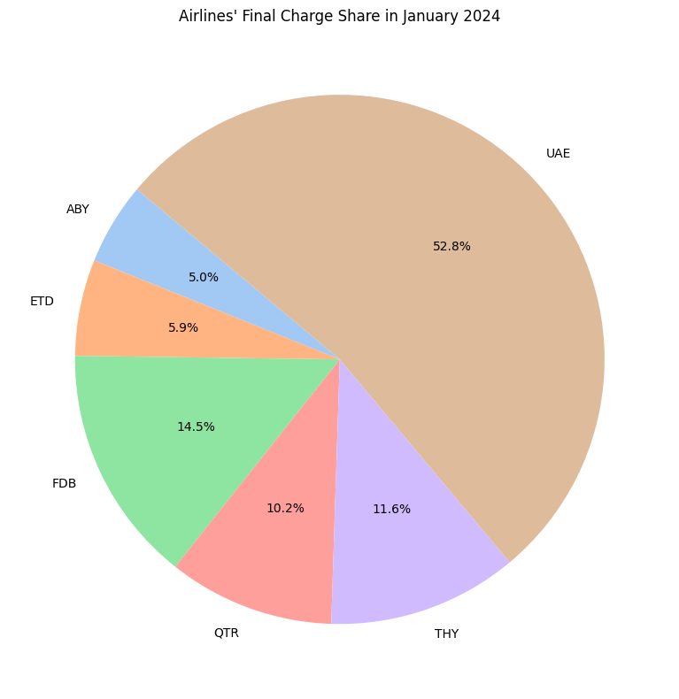

```python
# 1. Filter for top rank = 1
top_airlines = df_flight[df_flight['rank'] == 1]

# 2. Count how many times each airline was rank 1
rank_counts = top_airlines['airline'].value_counts()

# 3. Sum of final_charge for each airline for whole month
monetary_sum = df_flight.groupby('airline')['final_charge'].sum()

# 4. Combine both into a DataFrame
combined = pd.DataFrame({
    'top_rank_count': rank_counts,
    'total_final_charge': monetary_sum
}).fillna(0)

# Optional: Normalize if needed
combined['total_final_charge'] = combined['total_final_charge'].astype(float)
combined['score'] = combined['top_rank_count'] + (combined['total_final_charge'] / combined['total_final_charge'].max())

# 5. Plot Pie chart for monetary contribution
plt.figure(figsize=(8, 8))
colors = sns.color_palette('pastel')[0:len(combined)]

plt.pie(
    combined['total_final_charge'],
    labels=combined.index,
    autopct='%1.1f%%',
    startangle=140,
    colors=colors
)
plt.title("Airlines' Final Charge Share in January 2024")
plt.tight_layout()
plt.show()
```

```python
import folium
from geopy.distance import geodesic
```

```python
# Helper to convert DMS (degrees, minutes, seconds) to decimal
def dms_to_decimal(d, m, s, direction):
    decimal = d + m / 60 + s / 3600
    if direction in ['S', 'W']:
        return -decimal
    return decimal
```

```python
def parse_dms_string(dms_str):
    # Split on the "-" between lat and lon
    lat_str, lon_str = dms_str.split('-')
    # Extract components
    lat_parts = lat_str.strip().split()
    lon_parts = lon_str.strip().split()
    return (
        (int(lat_parts[0]), int(lat_parts[1]), int(lat_parts[2]), lat_parts[3]),
        (int(lon_parts[0]), int(lon_parts[1]), int(lon_parts[2]), lon_parts[3])
    )
```

```python
%%sql result <<
select point, coordinate
from rfm.points;
```

Running query in 'postgresql://postgres:***@localhost:5432/lab'

505 rows affected.

```python
df2 = result.DataFrame()
```

```python
%%sql
result <<
SELECT
  max(distance) max,entry_point,exit_point
FROM
  rfm.f202401
WHERE
  length (airline) = 3
GROUP BY
  entry_point,exit_point
ORDER BY
   max(distance) desc limit 1;
```

Running query in 'postgresql://postgres:***@localhost:5432/lab'

1 rows affected.

```python
result
```

| max | entry_point | exit_point |
| --- | --- | --- |
| 1213.97 | AGINA | ASVIB |

```python
%%sql
result <<
select departure,destination
from rfm.f202401
where entry_point = 'AGINA' AND exit_point = 'ASVIB';
```

Running query in 'postgresql://postgres:***@localhost:5432/lab'

1 rows affected.

```python
result
```

| departure | destination |
| --- | --- |
| Frankfurt, Main, Germany | Mumbai, Jawaharlal Lal Nehru, India |

```python
# Coordinates dictionary
waypoints = dict(zip(df2['point'], df2['coordinate']))
```

```python
# Convert all to decimal degrees
coords = {}
for name, coord_str in waypoints.items():
    lat_dms, lon_dms = parse_dms_string(coord_str)
    lat = dms_to_decimal(*lat_dms)
    lon = dms_to_decimal(*lon_dms)
    coords[name] = (lat, lon)
```

```python
# Function to plot two points with distance
def plot_two_points_with_distance(name1, name2):
    if name1 not in coords or name2 not in coords:
        print("One or both point names not found.")
        return

    lat1, lon1 = coords[name1]
    lat2, lon2 = coords[name2]

    # Calculate distance
    point1 = (lat1, lon1)
    point2 = (lat2, lon2)
    distance = geodesic(point1, point2).nautical  # ✅ Gives you distance in nautical miles

    # Midpoint for map centering
    mid_lat = (lat1 + lat2) / 2
    mid_lon = (lon1 + lon2) / 2

    # Create the map centered at the midpoint
    m = folium.Map(location=[mid_lat, mid_lon], zoom_start=6)

    # Add markers for both points
    folium.Marker([lat1, lon1], popup=name1, tooltip=name1).add_to(m)
    folium.Marker([lat2, lon2], popup=name2, tooltip=name2).add_to(m)

    # Draw a line between the two points
    folium.PolyLine(locations=[[lat1, lon1], [lat2, lon2]], color="blue").add_to(m)

    # Add the distance label on the map near the line
    folium.Marker(
        location=[(lat1 + lat2 + 0.4)/2, (lon1 + lon2 + 0.4)/2],
        icon=folium.DivIcon(html=f'<div style="font-size: 12px; color: black;">{distance:.2f} N.M</div>')
    ).add_to(m)
    return m
```

```python
plot_two_points_with_distance('AGINA', 'ASVIB')
```

Make this Notebook Trusted to load map: File -> Trust Notebook

[interactive chart not shown]

[figure not shown]

# Comparing RFM, CLV, and FBR through chaos lens

- آیا این مدل‌ها می‌توانند رفتار آشوبناک از خود نشان دهند؟
- چه شرایطی برای بروز آشوب در این مدل‌ها لازم است؟
- نقش پارامترهای کنترلی در پایداری یا ناپایداری سیستم چیست؟
- آیا تغییرات کوچک در ورودی‌ها می‌تواند به تغییرات بزرگ در خروجی منجر شود؟
- کدام مدل ذاتاً برای تحلیل آشوب مناسب‌تر است؟
- چه تفاوتی میان مدل‌های تک‌بعدی و چندبعدی از نظر امکان بروز آشوب وجود دارد؟
- برای تحلیل آشوب در این مدل‌ها از چه ابزارهای ریاضی می‌توان استفاده کرد؟
- چگونه می‌توان رفتار آشوبناک را از رفتار تصادفی تشخیص داد؟
- آشوب چه اثری بر پیش‌بینی‌پذیری سیستم دارد؟
- شناخت آشوب چه کمکی به تصمیم‌گیری و کنترل سیستم می‌کند؟
- چه راه‌هایی برای جلوگیری یا کنترل ورود سیستم به ناحیه آشوب وجود دارد؟
- ارزش علمی و کاربردی تحلیل آشوب در این مدل‌ها چیست؟

## Revenue Pipeline: RFM → CLV → FBR

the actual theorems (Period-3 Theorem, Sharkovsky, the orbit diagram) apply to specific quadratic maps, not literally to CRM systems. The value here is using the same iterative structure to see when a revenue policy becomes unpredictable in the technical sense.

```
flowchart LR
    A["RFM
segments customers"] --> B["CLV
models the value of
retaining each segment"]
    B --> C["FBR
sets the price lever
to capture that value"]

    A --> D{"Segment-triggered
actions"}
    D --> E["Upsell
(↑ order value)"]
    D --> F["Cross-sell
(↑ basket size)"]
    D --> G["Repeat purchase
(↑ loyalty)"]

    E -.-> C
    F -.-> C
    G -.-> C
```

```
┌──────────────┐      ┌──────────────────┐      ┌────────────────────┐
│     RFM      │ ───▶ │       CLV        │ ───▶ │       FBR          │
│  segments    │      │ models value of  │      │ sets price lever   │
│  customers   │      │ retaining them   │      │ to capture value   │
└──────┬───────┘      └──────────────────┘      └──────────▲─────────┘
       │                                                   │
       │           triggers per-segment actions            │
       ▼                                                   │
┌─────────────────────────────────────────────────┐        │
│  Upsell (↑ order value)                         │────────┘
│  Cross-sell (↑ basket size)                     │────────┘
│  Repeat purchase (↑ loyalty)                    │────────┘
└─────────────────────────────────────────────────┘
```

We turn each model into a **feedback map** — this period's output feeds next period's input — the same setup as `Qc(x) = x² + c` or the logistic family `Fλ(x) = λx(1 − x)`.

### FBR — the natural chaos candidate

FBR already contains a feedback loop: raising the fee rate `R` reduces the number of flights `N` via elasticity. If `R` reacts each period to *last period's* traffic response, collapsing this into a single-variable recursion gives: $$ N_{n+1} = λ · N_n · (1 − N_n / N_{\max}) $$ where `λ` packages together the elasticity $E_d$ and your fee-adjustment aggressiveness. This is structurally identical to the logistic family.

- **λ < 3**: traffic settles to a stable equilibrium (single fixed point) — predictable revenue.
- **3 ≤ λ < 3.57...**: period-doubling bifurcations — traffic oscillates in 2-, 4-, 8-cycles (e.g., alternating high/low booking quarters).
- **λ ≥ 3.57... (Feigenbaum point)**: **chaos onset**. Small changes in fee-adjustment aggressiveness produce qualitatively different long-run traffic/revenue patterns.

### CLV — chaos only if retention is made endogenous

As stated, with `m`, `r`, `d` held constant: $$ CLV = m·r / (1 − r + d) $$ this is just a fixed point — no dynamics, no chaos possible. It becomes a chaos candidate only if you feed margin back into retention: $$ r_{n+1} = h(m_n) $$ where reinvesting margin into loyalty programs increases next-cohort retention but with diminishing/negative returns at high investment (over-discounting cannibalizes margin, which starves the *next* round of retention spend). That reinvestment loop is again logistic-shaped: $$ r_{n+1} = λ · r_n · (1 − r_n) $$ and chaos appears the same way — past a bifurcation threshold, the retention rate no longer converges to one stable `r*`, but bounces unpredictably cohort to cohort.

### RFM — chaos in the segment-migration map

RFM is naturally a **vector-valued** dynamical system: fractions of customers in each segment (Champions, Loyal, Potential, At-Risk, Lost) migrate period-to-period based on how aggressively you incentivize each bucket: $$ v_{n+1} = M(incentive) · v_n $$ where $v_n$ is the vector of segment population fractions at period `n`, and `M` is a (generally nonlinear, incentive-dependent) migration operator.

This is structurally a discrete competition/Markov-type map — multi-population discrete maps of this kind are known to exhibit chaos for certain incentive-elasticity parameter ranges (analogous to coupled logistic maps). Practically: if your win-back campaigns for "At-Risk" customers are too aggressive relative to how fast "Champions" churn down into that bucket, the segment proportions can start oscillating chaotically rather than settling into a stable customer-mix equilibrium — the RFM segment distribution could swing unpredictably quarter to quarter even under a fixed incentive *policy*.

### Bottom line

**FBR** is the model where this connection is tightest and most defensible mathematically — it already has an explicit price↔demand feedback loop built in, requiring no extra assumptions to become a genuine 1D chaotic map. **CLV** and **RFM** only connect to chaos once you explicitly make them iterative (a reinvestment loop for CLV, a segment-migration map for RFM) rather than treating them as one-shot formulas.

[output not shown]

[output not shown]

| معیار تحلیل آشوب | FBR (کارمزد-محور) | CLV (ارزش طول عمر) | RFM (رفتار مشتری) |
| --- | --- | --- | --- |
| **نوع پویایی** | نگاشت غیرخطی مستقیم | بازخورد ایستا به پویا | سیستم دینامیکی برداری |
| **منبع اصلی آشوب** | کشش قیمت/کارمزد | نرخ بازسرمایه‌گذاری | تغییر وضعیت در فضای ویژگی‌ها |
| **پیچیدگی تحلیل** | تک‌بعدی (نمودار دوشاخه‌ای) | وابسته به متغیرهای زمانی | چندبعدی (فضای حالت پیچیده) |
| **پیش‌بینی‌پذیری** | λ بسیار حساس به | محدود به دوره بازخورد | به‌شدت ناپایدار در بلندمدت |
| **راهبرد کنترل** | سقف‌گذاری گامِ کارمزد | تعدیل نرخ جذب/نگهداشت | میراسازی انتقال دسته‌ها |

### منابع، داده‌ها و ابزارهای مورد استفاده

#### منبع داده

- داده‌های مورد استفاده شامل مجموعه داده‌های طبقه‌بندی‌شده و گزارش‌شده از پروازهای عبوری از فضای هوایی ایران در بازه زمانی 2023 تا 2025 است که توسط شرکت فرودگاه ها در اختیار پروژه قرار گرفته است.

#### منابع علمی

- Devaney, R. L. (2020). *A First Course in Chaotic Dynamical Systems: Theory and Experiment*. Chapman and Hall/CRC.

#### ابزارهای نرم‌افزاری و تحلیلی

- Python 3.x — پیاده‌سازی الگوریتم‌ها و تحلیل داده‌ها
- JupyterLab — توسعه، مستندسازی و اجرای کدهای تحلیلی
- Pandas — پاک‌سازی، پردازش و تحلیل داده‌ها
- NumPy — محاسبات عددی و آرایه‌ای
- Matplotlib — تولید نمودارها و مصورسازی داده‌ها
- Seaborn — مصورسازی آماری و تحلیل اکتشافی داده‌ها
- Git — کنترل نسخه و مدیریت تغییرات پروژه
- GitHub — نگهداری کدها، مستندسازی و مدیریت مخزن پروژه

#### ابزارهای هوش مصنوعی

- OpenAI ChatGPT — کمک در نگارش علمی، بازبینی متن، قالب‌بندی و مستندسازی
- Google NotebookLM — سازمان‌دهی منابع، یادداشت‌ها و استخراج نکات کلیدی
- Anthropic Claude — بازبینی نگارشی، پیشنهاد ساختار و بهبود بیان علمی

تمامی تحلیل‌ها، نتایج و تفسیرهای ارائه‌شده در این گزارش توسط نویسنده بررسی و تأیید شده‌اند. ابزارهای نرم‌افزاری و هوش مصنوعی صرفاً برای پردازش داده‌ها، تحلیل، مستندسازی و بهبود کیفیت نگارش مورد استفاده قرار گرفته‌اند.